# Data Exploration on Japanese Population Density

Emily Mendez

## 1. Dataset

This dataset is a subset from the United Nations Department of Economics and Social Affairs world population prospect data (a link to this set is provided below). The original dataset contained approximately 43,473 observations, 55 indicators, and location notes. By specifically focusing on the Japanese population from 1950 to 2022, I was able to subset the data to a 73 55 dimension. Factors studied in this set include various quantitative variables, such as total population, population density, median age, etc.

https://population.un.org/wpp/Download/Standard/MostUsed/

The data in this proposal will be used to explore the relationships between variables in order to determine which factors affect the population density. With the data we are also able to analyze how each factor changes by time.

**Population Subset Description**

The variables included in the dataset will be listed below along with their designated descriptions and measurement units.

```
## [1] 73 55
```

| IndicatorNo | Topic | Indicator | IndicatorName | Unit |
| --- | --- | --- | --- | --- |
| 1 | Population | TPopulation1Jan | Total Population, as of 1 January | thousands |
| 2 | Population | TPopulation1July | Total Population, as of 1 July | thousands |
| 3 | Population | TPopulationMale1July | Male Population, as of 1 July | thousands |
| 4 | Population | TPopulationFemale1July | Female Population, as of 1 July | thousands |
| 5 | Population | PopDensity | Population Density, as of 1 July | persons per square km |
| 6 | Population | PopSexRatio | Population Sex Ratio, as of 1 July | males per 100 females |
| 7 | Population | MedianAgePop | Median Age, as of 1 July | years |
| 8 | Population | NatChange | Natural Change, Births minus Deaths | thousands |
| 9 | Population | NatChangeRT | Rate of Natural Change | per 1,000 population |
| 10 | Population | PopChange | Population Change | thousands |
| 11 | Population | PopGrowthRate | Population Growth Rate | percentage |
| 12 | Population | DoublingTime | Population Annual Doubling Time | years |
| 13 | Fertility | Births | Births | thousands |
| 14 | Fertility | Births1519 | Births by women aged 15 to 19 | thousands |
| 15 | Fertility | CBR | Crude Birth Rate | births per 1,000 population |
| 16 | Fertility | TFR | Total Fertility Rate | live births per woman |
| 17 | Fertility | NRR | Net Reproduction Rate | surviving daughters per woman |
| 18 | Fertility | MAC | Mean Age Childbearing | years |
| 19 | Fertility | SRB | Sex Ratio at Birth | males per 100 female births |
| 20 | Mortality | Deaths | Total Deaths | thousands |
| 21 | Mortality | DeathsMale | Male Deaths | thousands |
| 22 | Mortality | DeathsFemale | Female Deaths | thousands |
| 23 | Mortality | CDR | Crude Death Rate | deaths per 1,000 population |
| 24 | Mortality | LEx | Life Expectancy at Birth, both sexes | years |
| 25 | Mortality | LExMale | Male Life Expectancy at Birth | years |
| 26 | Mortality | LExFemale | Female Life Expectancy at Birth | years |
| 27 | Mortality | LE15 | Life Expectancy at Age 15, both sexes | years |
| 28 | Mortality | LE15Male | Male Life Expectancy at Age 15 | years |
| 29 | Mortality | LE15Female | Female Life Expectancy at Age 15 | years |
| 30 | Mortality | LE65 | Life Expectancy at Age 65, both sexes | years |
| 31 | Mortality | LE65Male | Male Life Expectancy at Age 65 | years |
| 32 | Mortality | LE65Female | Female Life Expectancy at Age 65 | years |
| 33 | Mortality | LE80 | Life Expectancy at Age 80, both sexes | years |
| 34 | Mortality | LE80Male | Male Life Expectancy at Age 80 | years |
| 35 | Mortality | LE80Female | Female Life Expectancy at Age 80 | years |
| 36 | Mortality | InfantDeaths | Infant Deaths, under age 1 | thousands |
| 37 | Mortality | IMR | Infant Mortality Rate | infant deaths per 1,000 live births |
| 38 | Mortality | LBsurvivingAge1 | Live births Surviving to Age 1 | thousands |
| 39 | Mortality | Under5Deaths | Deaths under age 5 | thousands |
| 40 | Mortality | Q5 | Under-five Mortality Rate | deaths under age 5 per 1,000 live births |
| 41 | Mortality | Q0040 | Mortality before Age 40, both sexes | deaths under age 40 per 1,000 live births |
| 42 | Mortality | Q0040Male | Male mortality before Age 40 | deaths under age 40 per 1,000 male live births |
| 43 | Mortality | Q0040Female | Female mortality before Age 40 | deaths under age 40 per 1,000 female live births |
| 44 | Mortality | Q0060 | Mortality before Age 60, both sexes | deaths under age 60 per 1,000 live births |
| 45 | Mortality | Q0060Male | Male mortality before Age 60 | deaths under age 60 per 1,000 male live births |
| 46 | Mortality | Q0060Female | Female mortality before Age 60 | deaths under age 60 per 1,000 female live births |
| 47 | Mortality | Q1550 | Mortality between Age 15 and 50, both sexes | deaths under age 50 per 1,000 alive at age 15 |
| 48 | Mortality | Q1550Male | Male mortality between Age 15 and 50 | deaths under age 50 per 1,000 males alive at age 15 |
| 49 | Mortality | Q1550Female | Female mortality between Age 15 and 50 | deaths under age 50 per 1,000 females alive at age 15 |
| 50 | Mortality | Q1560 | Mortality between Age 15 and 60, both sexes | deaths under age 60 per 1,000 alive at age 15 |
| 51 | Mortality | Q1560Male | Male mortality between Age 15 and 60 | deaths under age 60 per 1,000 males alive at age 15 |
| 52 | Mortality | Q1560Female | Female mortality between Age 15 and 60 | deaths under age 60 per 1,000 females alive at age 15 |
| 53 | Migration | NetMigrations | Net Number of Migrants | thousands |
| 54 | Migration | CNMR | Net Migration Rate | per 1,000 population |

United Nations, Department of Economic and Social Affairs, Population Division (2022). World Population Prospects 2022, Online Edition.

**Data indicator type**

```r
attach(JapanPop)
sapply(JapanPop,class)
```

```
##                   Time        TPopulation1Jan       TPopulation1July
##              "integer"              "numeric"              "numeric"
##   TPopulationMale1July TPopulationFemale1July             PopDensity
##              "numeric"              "numeric"              "numeric"
##            PopSexRatio           MedianAgePop              NatChange
##              "numeric"              "numeric"              "numeric"
##            NatChangeRT              PopChange          PopGrowthRate
##              "numeric"              "numeric"              "numeric"
##           DoublingTime                 Births             Births1519
##              "numeric"              "numeric"              "numeric"
##                    CBR                    TFR                    NRR
##              "numeric"              "numeric"              "numeric"
##                    MAC                    SRB                 Deaths
##              "numeric"              "numeric"              "numeric"
##             DeathsMale           DeathsFemale                    CDR
##              "numeric"              "numeric"              "numeric"
##                    LEx                LExMale              LExFemale
##              "numeric"              "numeric"              "numeric"
##                   LE15               LE15Male             LE15Female
##              "numeric"              "numeric"              "numeric"
##                   LE65               LE65Male             LE65Female
##              "numeric"              "numeric"              "numeric"
##                   LE80               LE80Male             LE80Female
##              "numeric"              "numeric"              "numeric"
##           InfantDeaths                    IMR        LBsurvivingAge1
##              "numeric"              "numeric"              "numeric"
##           Under5Deaths                     Q5                  Q0040
##              "numeric"              "numeric"              "numeric"
##              Q0040Male            Q0040Female                  Q0060
##              "numeric"              "numeric"              "numeric"
##              Q0060Male            Q0060Female                  Q1550
##              "numeric"              "numeric"              "numeric"
##              Q1550Male            Q1550Female                  Q1560
##              "numeric"              "numeric"              "numeric"
##              Q1560Male            Q1560Female          NetMigrations
##              "numeric"              "numeric"              "numeric"
##                   CNMR
##              "numeric"
```

```r
#The data is mostly numeric, with the exception of time which is an integer.
```

**Summary of data**

```r
summary(JapanPop)
```

```
##       Time      TPopulation1Jan  TPopulation1July TPopulationMale1July
##  Min.   :1950   Min.   : 83656   Min.   : 84353   Min.   :41334
##  1st Qu.:1968   1st Qu.:102184   1st Qu.:102819   1st Qu.:50570
##  Median :1986   Median :121432   Median :121710   Median :59944
##  Mean   :1986   Mean   :114504   Mean   :114777   Mean   :56273
##  3rd Qu.:2004   3rd Qu.:126471   3rd Qu.:126555   3rd Qu.:61827
##  Max.   :2022   Max.   :128131   Max.   :128117   Max.   :62452
##
##  TPopulationFemale1July   PopDensity     PopSexRatio     MedianAgePop
##  Min.   :43019          Min.   :223.9   Min.   :94.55   Min.   :21.20
##  1st Qu.:52250          1st Qu.:272.9   1st Qu.:95.56   1st Qu.:27.57
##  Median :61767          Median :323.0   Median :96.48   Median :34.99
##  Mean   :58505          Mean   :304.6   Mean   :96.23   Mean   :34.81
##  3rd Qu.:64696          3rd Qu.:335.8   3rd Qu.:96.91   3rd Qu.:42.10
##  Max.   :65690          Max.   :340.0   Max.   :97.31   Max.   :48.74
##
##    NatChange        NatChangeRT       PopChange      PopGrowthRate
##  Min.   :-756.02   Min.   :-6.079   Min.   :-668.4   Min.   :-0.536
##  1st Qu.:  26.96   1st Qu.: 0.212   1st Qu.: 162.8   1st Qu.: 0.128
##  Median : 570.10   Median : 4.684   Median : 560.0   Median : 0.458
##  Mean   : 497.01   Mean   : 4.962   Mean   : 547.5   Mean   : 0.535
##  3rd Qu.:1057.01   3rd Qu.:10.574   3rd Qu.:1010.3   3rd Qu.: 1.037
##  Max.   :1455.42   Max.   :17.265   Max.   :1465.7   Max.   : 1.652
##
##   DoublingTime        Births         Births1519          CBR
##  Min.   : 41.96   Min.   : 814.7   Min.   : 7.597   Min.   : 6.571
##  1st Qu.: 55.93   1st Qu.:1128.4   1st Qu.:14.449   1st Qu.: 8.843
##  Median : 66.05   Median :1359.3   Median :16.912   Median :11.169
##  Mean   : 72.94   Mean   :1449.3   Mean   :17.996   Mean   :13.210
##  3rd Qu.: 81.21   3rd Qu.:1771.1   3rd Qu.:19.231   3rd Qu.:17.836
##  Max.   :134.33   Max.   :2389.2   Max.   :54.936   Max.   :28.343
##  NA's   :37
##       TFR             NRR              MAC             SRB
##  Min.   :1.274   Min.   :0.6150   Min.   :27.41   Min.   :105.0
##  1st Qu.:1.388   1st Qu.:0.6695   1st Qu.:27.83   1st Qu.:105.4
##  Median :1.681   Median :0.8066   Median :28.99   Median :105.6
##  Mean   :1.757   Mean   :0.8244   Mean   :29.08   Mean   :105.7
##  3rd Qu.:2.058   3rd Qu.:0.9463   3rd Qu.:29.91   3rd Qu.:105.9
##  Max.   :3.660   Max.   :1.5075   Max.   :31.46   Max.   :107.2
##
```

[output cut: 57 more lines]

```
##  Min.   : 22.74   Min.   : 13.69   Min.   : 44.45   Min.   : 56.56
##  1st Qu.: 39.69   1st Qu.: 20.02   1st Qu.: 69.36   1st Qu.: 92.68
##  Median : 50.05   Median : 26.04   Median : 89.28   Median :119.57
##  Mean   : 63.51   Mean   : 40.48   Mean   :110.43   Mean   :137.47
##  3rd Qu.: 81.05   3rd Qu.: 48.88   3rd Qu.:141.15   3rd Qu.:176.23
##  Max.   :187.45   Max.   :164.50   Max.   :290.34   Max.   :317.76
##
##   Q1560Female     NetMigrations         CNMR
##  Min.   : 31.97   Min.   :-79.34   Min.   :-0.8640
##  1st Qu.: 45.24   1st Qu.:-12.93   1st Qu.:-0.1060
##  Median : 58.43   Median : 41.49   Median : 0.3500
##  Mean   : 83.57   Mean   : 50.50   Mean   : 0.3878
##  3rd Qu.:108.46   3rd Qu.:116.28   3rd Qu.: 1.0400
##  Max.   :262.30   Max.   :183.95   Max.   : 1.4640
##
```

Observing the summary output, many variables seem to have a wide range of values due to being population data. Some variables also seem to have quite a range between their mean and medians such as IMR, Infant deaths, Under5deaths, etc. The summary data also explains the difference between the mean and median grows as the mean passes one hundred.

## 2. Preparing the data

After loading, prepare the data by deleting NA values from rows.

```r
JapanPop=read.csv('/Users/admin/Documents/Csvv/japan.csv',header=TRUE)
Finding_NaValues=function(data1){
  temp=(ifelse(is.na(data1)=="TRUE",1,0)==1)
  temp1=which(temp>0)
  temp2=which(colSums(temp)>0)
  out=cbind(temp1,temp2)
  print(out)
}
Finding_NaValues(JapanPop)
```

```
##       temp1 temp2
##  [1,]   913    13
##  [2,]   914    13
##  [3,]   915    13
##  [4,]   916    13
##  [5,]   917    13
##  [6,]   918    13
##  [7,]   919    13
##  [8,]   920    13
##  [9,]   921    13
## [10,]   922    13
## [11,]   923    13
## [12,]   924    13
## [13,]   925    13
## [14,]   926    13
```

[output cut: 23 more lines]

In this case it seems that all our NA values are in column 13; therefore, we will remove the column.

```r
JapanPop=JapanPop[,-13]
```

**Investigating Collinearity**

Checking the correlation between variables by using a correlation matrix will assist in finding other indicators of concern and help in reducing the dimension size. These factors that have high correlation among themselves indicate collinearity.

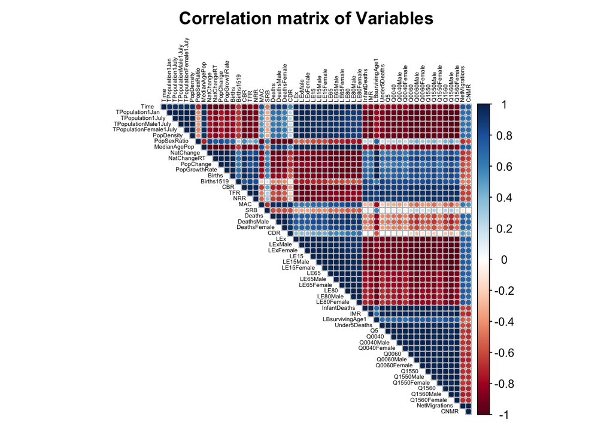

```r
library(corrplot) #loading correlation plot maker
corrPL=round(cor(JapanPop),3)
corrplot(corrPL, method="circle",type = "upper",
         title="Correlation matrix of Variables",
         mar = c(1,0,2,0),
         na.label.col = "white",
         tl.cex = 0.4,
         tl.col = "black")
```

To assess collinearity, we have already examined the correlation matrix. Now lets further examine a snippet of the data.

```r
knitr::kable(corrPL[1:30,1:6],format="markdown")
```

|  | Time | TPopulation1Jan | TPopulation1July | TPopulationMale1July | TPopulationFemale1July | PopDensity |
| --- | --- | --- | --- | --- | --- | --- |
| Time | 1.000 | 0.926 | 0.922 | 0.907 | 0.934 | 0.922 |
| TPopulation1Jan | 0.926 | 1.000 | 1.000 | 0.999 | 1.000 | 1.000 |
| TPopulation1July | 0.922 | 1.000 | 1.000 | 0.999 | 0.999 | 1.000 |
| TPopulationMale1July | 0.907 | 0.999 | 0.999 | 1.000 | 0.997 | 0.999 |
| TPopulationFemale1July | 0.934 | 1.000 | 0.999 | 0.997 | 1.000 | 0.999 |
| PopDensity | 0.922 | 1.000 | 1.000 | 0.999 | 0.999 | 1.000 |
| PopSexRatio | -0.712 | -0.414 | -0.403 | -0.369 | -0.435 | -0.403 |
| MedianAgePop | 0.999 | 0.925 | 0.920 | 0.906 | 0.933 | 0.920 |
| NatChange | -0.939 | -0.783 | -0.775 | -0.753 | -0.795 | -0.775 |
| NatChangeRT | -0.967 | -0.863 | -0.856 | -0.839 | -0.871 | -0.856 |
| PopChange | -0.915 | -0.761 | -0.753 | -0.731 | -0.772 | -0.753 |
| PopGrowthRate | -0.949 | -0.847 | -0.840 | -0.823 | -0.854 | -0.840 |
| Births | -0.906 | -0.820 | -0.813 | -0.798 | -0.826 | -0.813 |
| Births1519 | -0.661 | -0.663 | -0.661 | -0.659 | -0.662 | -0.661 |
| CBR | -0.940 | -0.933 | -0.929 | -0.921 | -0.935 | -0.929 |
| TFR | -0.861 | -0.897 | -0.895 | -0.892 | -0.898 | -0.895 |
| NRR | -0.880 | -0.897 | -0.894 | -0.888 | -0.898 | -0.894 |
| MAC | 0.784 | 0.543 | 0.533 | 0.503 | 0.560 | 0.533 |
| SRB | -0.476 | -0.336 | -0.328 | -0.310 | -0.345 | -0.328 |
| Deaths | 0.876 | 0.640 | 0.632 | 0.603 | 0.657 | 0.632 |
| DeathsMale | 0.900 | 0.680 | 0.672 | 0.645 | 0.697 | 0.672 |
| DeathsFemale | 0.850 | 0.600 | 0.591 | 0.561 | 0.617 | 0.591 |
| CDR | 0.576 | 0.244 | 0.233 | 0.198 | 0.265 | 0.233 |
| LEx | 0.970 | 0.978 | 0.976 | 0.970 | 0.981 | 0.976 |
| LExMale | 0.972 | 0.975 | 0.974 | 0.967 | 0.979 | 0.974 |
| LExFemale | 0.968 | 0.979 | 0.977 | 0.970 | 0.982 | 0.977 |
| LE15 | 0.988 | 0.968 | 0.965 | 0.955 | 0.973 | 0.965 |
| LE15Male | 0.990 | 0.961 | 0.958 | 0.948 | 0.966 | 0.958 |
| LE15Female | 0.986 | 0.970 | 0.968 | 0.958 | 0.975 | 0.968 |
| LE65 | 0.993 | 0.933 | 0.929 | 0.915 | 0.941 | 0.929 |

As shown most of the variables are correlated to each other, there seems to be little variance among the variables. Except CDR seems to be a good variable to use, a predictor variable in a linear regression model.

## 3. Plotting variables

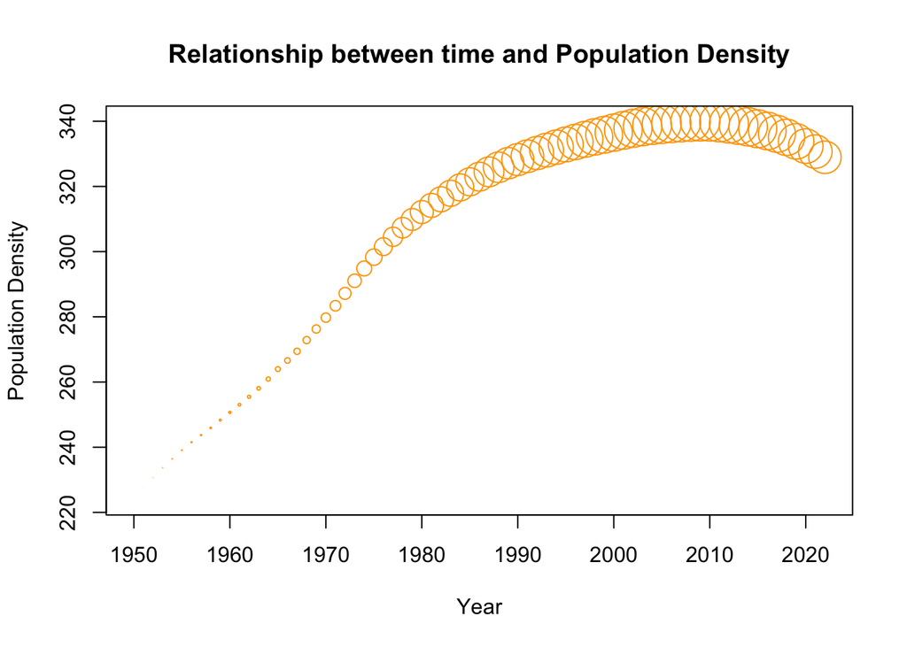

```r
diffs=(PopDensity-min(PopDensity))
sizetmp = (2* ( diffs + 1) / max(diffs))^2
pt_sizes = sizetmp

plot(PopDensity~Time, xlab="Year",ylab="Population Density",
     main="Relationship between time and Population Density",
     col="orange",
     cex=pt_sizes)
```

This graph shows the relationship between years and the population density of Japan. As the years go on the population density begins to decrease. Lets further investigate by examining the various factors such as births and deaths.

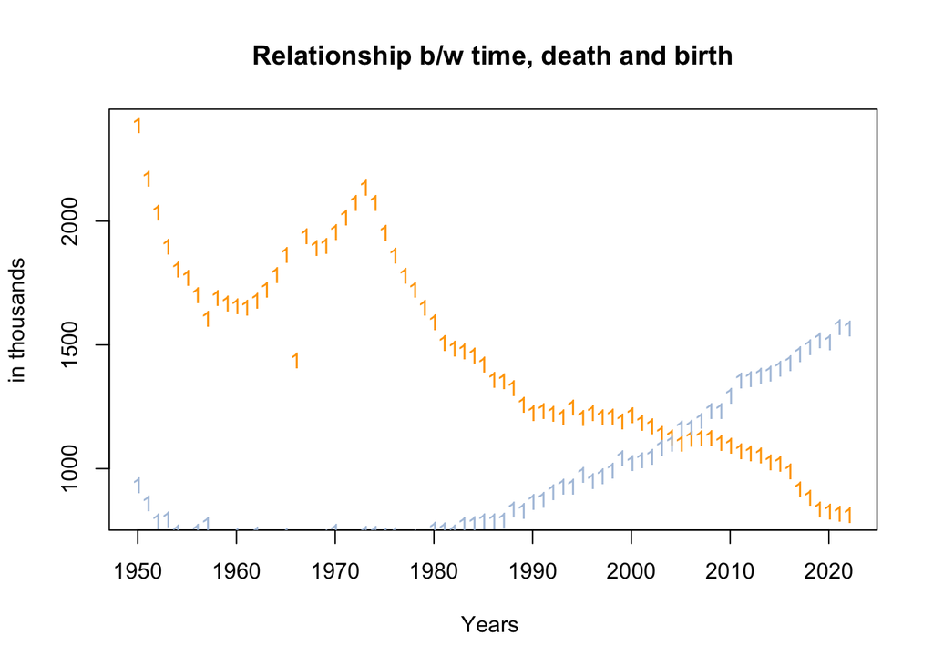

```r
matplot(y=Births,x=Time,type = "p",col="orange",ylab = "in thousands",xlab = "Years ")
matlines(y=Deaths,x=Time,type = "p",col = "lightsteelblue")
title(main  = "Relationship b/w time, death and birth",cex.lab = 2)
```

```r
#The orange line indicated Births and the blue line indicates deaths.
```

As the years pass by the number of deaths increase and the number of births decrease. This means there are more people dying than being born which is a possible factor to consider for a decease in population growth and density.

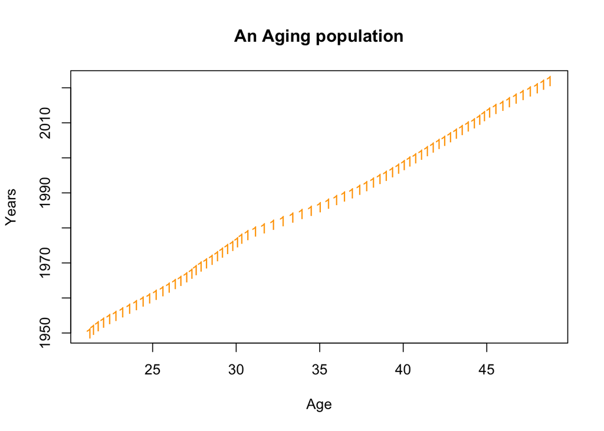

```r
matplot(y=Time,x=MedianAgePop,type = "p",col="orange",ylab = "Years",xlab = "Age")
title(main  = "An Aging population",cex.lab = 2)
```

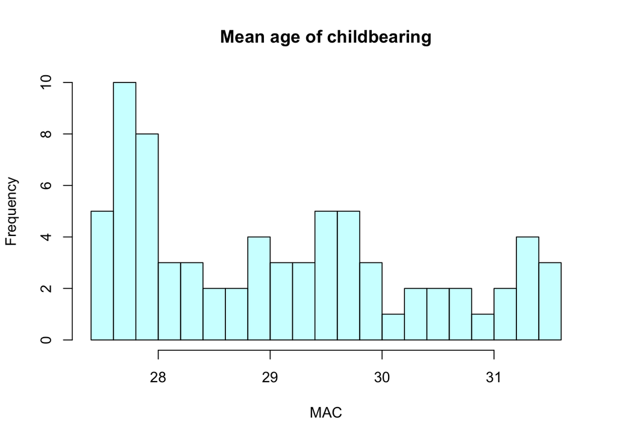

```r
hist(MAC,breaks = 15,col=rgb(0,1,1,1/4),main="Mean age of childbearing")
```

```r
#The orange line indicated median age of the population
```

The first plot represents the median age increasing with time. Due to the increase in age in later years and the mean age of childbearing staying relatively the same, we can assume that the aging population affects population density. In the next model we will evaluate the correlation.

```r
model1=lm(PopGrowthRate~MedianAgePop)
summary(model1)
```

```
##
## Call:
## lm(formula = PopGrowthRate ~ MedianAgePop)
##
## Residuals:
##      Min       1Q   Median       3Q      Max
## -0.44495 -0.07275 -0.00874  0.06912  0.43249
##
## Coefficients:
##               Estimate Std. Error t value Pr(>|t|)
## (Intercept)   2.801380   0.086338   32.45   <2e-16 ***
## MedianAgePop -0.065109   0.002413  -26.98   <2e-16 ***
## ---
## Signif. codes:  0 '***' 0.001 '**' 0.01 '*' 0.05 '.' 0.1 ' ' 1
##
## Residual standard error: 0.1707 on 71 degrees of freedom
## Multiple R-squared:  0.9111, Adjusted R-squared:  0.9099
## F-statistic: 728.1 on 1 and 71 DF,  p-value: < 2.2e-16
```

As we expected, the r^2 value is 0.91 meaning 91% of the variability in the mean of population growth rate can be explained by this linear model.

**In Conclusion** Most factors in this plot are highly correlated with population density, though many of these factors are also highly correlated to each other. Therefore, there is a need to eliminate some factors in order to produce a better fit linear model, if we were to create a linear regression model of some sort, due to the nature of this data, one variable would be enough to create predictive value because of the high correlations.

## References

1. United Nations, Department of Economic and Social Affairs, Population Division (2022). World Population Prospects 2022, Online Edition.